# FDC models running - post Glenys one-hot encoding

### The structure of the notebook is as follows:

1. Libraries Imported
2. Training dataset imported and categorical columns one-hot encoded (EXCEPT cat10)
3. Test dataset imported and categorical columns one-hot encoded (EXCEPT cat10)
4. cat10 column is extracted, merged, one-hot encoded, split and merged with original datasets (refer code for more details)

### (1) Importing Libraries

```python
import pandas as pd
import numpy as np
import matplotlib.pyplot as plt
print('libraries imported')
```

```
libraries imported
```

### (2) Training dataset

#### Downloading the dataset

(Make sure to change the file path when you run it on your systems)

```python
train_set = pd.read_csv("/Users/fede.dicerbo/Desktop/practical2/train.csv", header=0)
print ('train data imported')
```

```
train data imported
```

```python
train_set.head()
```

|  | id | cat0 | cat1 | cat2 | cat3 | cat4 | cat5 | cat6 | cat7 | cat8 | ... | cont2 | cont3 | cont4 | cont5 | cont6 | cont7 | cont8 | cont9 | cont10 | target |
| --- | --- | --- | --- | --- | --- | --- | --- | --- | --- | --- | --- | --- | --- | --- | --- | --- | --- | --- | --- | --- | --- |
| 0 | 0 | A | I | A | B | B | BI | A | S | Q | ... | 0.759439 | 0.795549 | 0.681917 | 0.621672 | 0.592184 | 0.791921 | 0.815254 | 0.965006 | 0.665915 | 0 |
| 1 | 1 | A | I | A | A | E | BI | K | W | AD | ... | 0.386385 | 0.541366 | 0.388982 | 0.357778 | 0.600044 | 0.408701 | 0.399353 | 0.927406 | 0.493729 | 0 |
| 2 | 2 | A | K | A | A | E | BI | A | E | BM | ... | 0.343255 | 0.616352 | 0.793687 | 0.552877 | 0.352113 | 0.388835 | 0.412303 | 0.292696 | 0.549452 | 0 |
| 3 | 3 | A | K | A | C | E | BI | A | Y | AD | ... | 0.831147 | 0.807807 | 0.800032 | 0.619147 | 0.221789 | 0.897617 | 0.633669 | 0.760318 | 0.934242 | 0 |
| 4 | 4 | A | I | G | B | E | BI | C | G | Q | ... | 0.338818 | 0.277308 | 0.610578 | 0.128291 | 0.578764 | 0.279167 | 0.351103 | 0.357084 | 0.328960 | 1 |

5 rows × 32 columns

```python
train_set_copy = train_set #making a copy of the dataset to work with
train_set_copy.head()
```

|  | id | cat0 | cat1 | cat2 | cat3 | cat4 | cat5 | cat6 | cat7 | cat8 | ... | cont2 | cont3 | cont4 | cont5 | cont6 | cont7 | cont8 | cont9 | cont10 | target |
| --- | --- | --- | --- | --- | --- | --- | --- | --- | --- | --- | --- | --- | --- | --- | --- | --- | --- | --- | --- | --- | --- |
| 0 | 0 | A | I | A | B | B | BI | A | S | Q | ... | 0.759439 | 0.795549 | 0.681917 | 0.621672 | 0.592184 | 0.791921 | 0.815254 | 0.965006 | 0.665915 | 0 |
| 1 | 1 | A | I | A | A | E | BI | K | W | AD | ... | 0.386385 | 0.541366 | 0.388982 | 0.357778 | 0.600044 | 0.408701 | 0.399353 | 0.927406 | 0.493729 | 0 |
| 2 | 2 | A | K | A | A | E | BI | A | E | BM | ... | 0.343255 | 0.616352 | 0.793687 | 0.552877 | 0.352113 | 0.388835 | 0.412303 | 0.292696 | 0.549452 | 0 |
| 3 | 3 | A | K | A | C | E | BI | A | Y | AD | ... | 0.831147 | 0.807807 | 0.800032 | 0.619147 | 0.221789 | 0.897617 | 0.633669 | 0.760318 | 0.934242 | 0 |
| 4 | 4 | A | I | G | B | E | BI | C | G | Q | ... | 0.338818 | 0.277308 | 0.610578 | 0.128291 | 0.578764 | 0.279167 | 0.351103 | 0.357084 | 0.328960 | 1 |

5 rows × 32 columns

```python
#removing the features from the target
y_train = train_set_copy[["target"]] #y_train contains the target
y_train.head()
```

|  | target |
| --- | --- |
| 0 | 0 |
| 1 | 0 |
| 2 | 0 |
| 3 | 0 |
| 4 | 1 |

```python
X_train = train_set_copy #X_train contains all the features
X_train.head()
```

|  | id | cat0 | cat1 | cat2 | cat3 | cat4 | cat5 | cat6 | cat7 | cat8 | ... | cont2 | cont3 | cont4 | cont5 | cont6 | cont7 | cont8 | cont9 | cont10 | target |
| --- | --- | --- | --- | --- | --- | --- | --- | --- | --- | --- | --- | --- | --- | --- | --- | --- | --- | --- | --- | --- | --- |
| 0 | 0 | A | I | A | B | B | BI | A | S | Q | ... | 0.759439 | 0.795549 | 0.681917 | 0.621672 | 0.592184 | 0.791921 | 0.815254 | 0.965006 | 0.665915 | 0 |
| 1 | 1 | A | I | A | A | E | BI | K | W | AD | ... | 0.386385 | 0.541366 | 0.388982 | 0.357778 | 0.600044 | 0.408701 | 0.399353 | 0.927406 | 0.493729 | 0 |
| 2 | 2 | A | K | A | A | E | BI | A | E | BM | ... | 0.343255 | 0.616352 | 0.793687 | 0.552877 | 0.352113 | 0.388835 | 0.412303 | 0.292696 | 0.549452 | 0 |
| 3 | 3 | A | K | A | C | E | BI | A | Y | AD | ... | 0.831147 | 0.807807 | 0.800032 | 0.619147 | 0.221789 | 0.897617 | 0.633669 | 0.760318 | 0.934242 | 0 |
| 4 | 4 | A | I | G | B | E | BI | C | G | Q | ... | 0.338818 | 0.277308 | 0.610578 | 0.128291 | 0.578764 | 0.279167 | 0.351103 | 0.357084 | 0.328960 | 1 |

5 rows × 32 columns

```python
X_train.drop('target', axis=1, inplace=True) #removing target from features
X_train.drop('id', axis=1, inplace=True)     #removing id column
X_train.head()
```

|  | cat0 | cat1 | cat2 | cat3 | cat4 | cat5 | cat6 | cat7 | cat8 | cat9 | ... | cont1 | cont2 | cont3 | cont4 | cont5 | cont6 | cont7 | cont8 | cont9 | cont10 |
| --- | --- | --- | --- | --- | --- | --- | --- | --- | --- | --- | --- | --- | --- | --- | --- | --- | --- | --- | --- | --- | --- |
| 0 | A | I | A | B | B | BI | A | S | Q | A | ... | 0.855349 | 0.759439 | 0.795549 | 0.681917 | 0.621672 | 0.592184 | 0.791921 | 0.815254 | 0.965006 | 0.665915 |
| 1 | A | I | A | A | E | BI | K | W | AD | F | ... | 0.328929 | 0.386385 | 0.541366 | 0.388982 | 0.357778 | 0.600044 | 0.408701 | 0.399353 | 0.927406 | 0.493729 |
| 2 | A | K | A | A | E | BI | A | E | BM | L | ... | 0.322749 | 0.343255 | 0.616352 | 0.793687 | 0.552877 | 0.352113 | 0.388835 | 0.412303 | 0.292696 | 0.549452 |
| 3 | A | K | A | C | E | BI | A | Y | AD | F | ... | 0.707663 | 0.831147 | 0.807807 | 0.800032 | 0.619147 | 0.221789 | 0.897617 | 0.633669 | 0.760318 | 0.934242 |
| 4 | A | I | G | B | E | BI | C | G | Q | A | ... | 0.274514 | 0.338818 | 0.277308 | 0.610578 | 0.128291 | 0.578764 | 0.279167 | 0.351103 | 0.357084 | 0.328960 |

5 rows × 30 columns

```python
X_train.info()
```

```
<class 'pandas.core.frame.DataFrame'>
RangeIndex: 300000 entries, 0 to 299999
Data columns (total 30 columns):
 #   Column  Non-Null Count   Dtype
---  ------  --------------   -----
 0   cat0    300000 non-null  object
 1   cat1    300000 non-null  object
 2   cat2    300000 non-null  object
 3   cat3    300000 non-null  object
 4   cat4    300000 non-null  object
 5   cat5    300000 non-null  object
 6   cat6    300000 non-null  object
 7   cat7    300000 non-null  object
 8   cat8    300000 non-null  object
 9   cat9    300000 non-null  object
```

[output cut: 22 more lines]

```python
#IGNORE THIS CELL

#code used to perform one-hot encoding for a single column

# X_train = pd.concat([X_train,pd.get_dummies(X_train['cat0'], prefix='cat0')],axis=1)
# X_train.drop('cat0', axis = 1, inplace = True)
# X_train.head()
```

```python
%%time

#using a loop to convert all categorical columns EXCEPT cat10
for col in ['cat0','cat1','cat2','cat3','cat4','cat5','cat6','cat7','cat8','cat9', 'cat11', 'cat12', 'cat13', 'cat14', 'cat15', 'cat16', 'cat17', 'cat18']:
    X_train = pd.concat([X_train,pd.get_dummies(X_train[col], prefix=col)],axis=1)
    X_train.drop(col, axis = 1, inplace = True)
```

```
CPU times: user 4.03 s, sys: 2.26 s, total: 6.29 s
Wall time: 7.57 s
```

```python
X_train.head()
```

|  | cat10 | cont0 | cont1 | cont2 | cont3 | cont4 | cont5 | cont6 | cont7 | cont8 | ... | cat16_C | cat16_D | cat17_A | cat17_B | cat17_C | cat17_D | cat18_A | cat18_B | cat18_C | cat18_D |
| --- | --- | --- | --- | --- | --- | --- | --- | --- | --- | --- | --- | --- | --- | --- | --- | --- | --- | --- | --- | --- | --- |
| 0 | LO | 0.629858 | 0.855349 | 0.759439 | 0.795549 | 0.681917 | 0.621672 | 0.592184 | 0.791921 | 0.815254 | ... | 0 | 1 | 0 | 0 | 0 | 1 | 0 | 1 | 0 | 0 |
| 1 | HJ | 0.370727 | 0.328929 | 0.386385 | 0.541366 | 0.388982 | 0.357778 | 0.600044 | 0.408701 | 0.399353 | ... | 0 | 0 | 0 | 0 | 0 | 1 | 0 | 1 | 0 | 0 |
| 2 | DJ | 0.502272 | 0.322749 | 0.343255 | 0.616352 | 0.793687 | 0.552877 | 0.352113 | 0.388835 | 0.412303 | ... | 0 | 1 | 0 | 0 | 0 | 1 | 0 | 1 | 0 | 0 |
| 3 | KV | 0.934242 | 0.707663 | 0.831147 | 0.807807 | 0.800032 | 0.619147 | 0.221789 | 0.897617 | 0.633669 | ... | 0 | 1 | 0 | 0 | 0 | 1 | 0 | 1 | 0 | 0 |
| 4 | DP | 0.254427 | 0.274514 | 0.338818 | 0.277308 | 0.610578 | 0.128291 | 0.578764 | 0.279167 | 0.351103 | ... | 0 | 0 | 0 | 0 | 0 | 1 | 0 | 1 | 0 | 0 |

5 rows × 336 columns

### (3) Test dataset

#### Downloading the dataset

(Make sure to change the file path before running the following lines of code on your systems)

```python
#importing test dataset
test_set = pd.read_csv("/Users/fede.dicerbo/Desktop/practical2/test.csv", header=0)
print ('test data imported')
```

```
test data imported
```

```python
test_set_copy = test_set #making a copy of the test dataset to work with
```

```python
test_set_copy.head()
```

|  | id | cat0 | cat1 | cat2 | cat3 | cat4 | cat5 | cat6 | cat7 | cat8 | ... | cont1 | cont2 | cont3 | cont4 | cont5 | cont6 | cont7 | cont8 | cont9 | cont10 |
| --- | --- | --- | --- | --- | --- | --- | --- | --- | --- | --- | --- | --- | --- | --- | --- | --- | --- | --- | --- | --- | --- |
| 0 | 5 | A | F | A | A | F | BI | A | AH | AX | ... | 0.735690 | 0.578366 | 0.723154 | 0.228037 | 0.356227 | 0.551249 | 0.655693 | 0.598331 | 0.359987 | 0.947489 |
| 1 | 6 | A | H | C | A | E | AB | I | F | N | ... | 0.313703 | 0.928885 | 0.516602 | 0.600169 | 0.795224 | 0.248987 | 0.654614 | 0.347944 | 0.565520 | 0.388580 |
| 2 | 8 | A | N | C | A | F | AB | A | AH | BC | ... | 0.448201 | 0.424876 | 0.344729 | 0.242073 | 0.270632 | 0.746740 | 0.335590 | 0.341238 | 0.252289 | 0.411592 |
| 3 | 9 | B | L | C | A | F | BI | A | E | AX | ... | 0.666092 | 0.598943 | 0.561971 | 0.806347 | 0.735983 | 0.538724 | 0.381566 | 0.481660 | 0.348514 | 0.325723 |
| 4 | 11 | A | F | A | B | F | BI | A | AH | I | ... | 0.772229 | 0.479572 | 0.767745 | 0.252454 | 0.354810 | 0.178920 | 0.763479 | 0.562491 | 0.466261 | 0.585781 |

5 rows × 31 columns

```python
X_test = test_set_copy                       #saving all the features in X_test
X_test.drop('id', axis = 1, inplace = True)  #dropping the id column
X_test.head()
```

|  | cat0 | cat1 | cat2 | cat3 | cat4 | cat5 | cat6 | cat7 | cat8 | cat9 | ... | cont1 | cont2 | cont3 | cont4 | cont5 | cont6 | cont7 | cont8 | cont9 | cont10 |
| --- | --- | --- | --- | --- | --- | --- | --- | --- | --- | --- | --- | --- | --- | --- | --- | --- | --- | --- | --- | --- | --- |
| 0 | A | F | A | A | F | BI | A | AH | AX | A | ... | 0.735690 | 0.578366 | 0.723154 | 0.228037 | 0.356227 | 0.551249 | 0.655693 | 0.598331 | 0.359987 | 0.947489 |
| 1 | A | H | C | A | E | AB | I | F | N | A | ... | 0.313703 | 0.928885 | 0.516602 | 0.600169 | 0.795224 | 0.248987 | 0.654614 | 0.347944 | 0.565520 | 0.388580 |
| 2 | A | N | C | A | F | AB | A | AH | BC | A | ... | 0.448201 | 0.424876 | 0.344729 | 0.242073 | 0.270632 | 0.746740 | 0.335590 | 0.341238 | 0.252289 | 0.411592 |
| 3 | B | L | C | A | F | BI | A | E | AX | A | ... | 0.666092 | 0.598943 | 0.561971 | 0.806347 | 0.735983 | 0.538724 | 0.381566 | 0.481660 | 0.348514 | 0.325723 |
| 4 | A | F | A | B | F | BI | A | AH | I | A | ... | 0.772229 | 0.479572 | 0.767745 | 0.252454 | 0.354810 | 0.178920 | 0.763479 | 0.562491 | 0.466261 | 0.585781 |

5 rows × 30 columns

```python
%%time

#using get_dummies() to one-hot encode all categorical columns EXCEPT cat10
for col in ['cat0','cat1','cat2','cat3','cat4','cat5','cat6','cat7','cat8','cat9','cat11', 'cat12', 'cat13', 'cat14', 'cat15', 'cat16', 'cat17', 'cat18']:
    X_test = pd.concat([X_test,pd.get_dummies(X_test[col], prefix=col)],axis=1)
    X_test.drop(col, axis = 1, inplace = True)
```

```
CPU times: user 2.94 s, sys: 1.8 s, total: 4.74 s
Wall time: 7.01 s
```

```python
X_test.head()
```

|  | cat10 | cont0 | cont1 | cont2 | cont3 | cont4 | cont5 | cont6 | cont7 | cont8 | ... | cat16_C | cat16_D | cat17_A | cat17_B | cat17_C | cat17_D | cat18_A | cat18_B | cat18_C | cat18_D |
| --- | --- | --- | --- | --- | --- | --- | --- | --- | --- | --- | --- | --- | --- | --- | --- | --- | --- | --- | --- | --- | --- |
| 0 | LF | 0.708120 | 0.735690 | 0.578366 | 0.723154 | 0.228037 | 0.356227 | 0.551249 | 0.655693 | 0.598331 | ... | 0 | 1 | 0 | 0 | 0 | 1 | 0 | 1 | 0 | 0 |
| 1 | MC | 0.611637 | 0.313703 | 0.928885 | 0.516602 | 0.600169 | 0.795224 | 0.248987 | 0.654614 | 0.347944 | ... | 0 | 0 | 0 | 0 | 0 | 1 | 0 | 1 | 0 | 0 |
| 2 | FN | 0.456289 | 0.448201 | 0.424876 | 0.344729 | 0.242073 | 0.270632 | 0.746740 | 0.335590 | 0.341238 | ... | 0 | 1 | 0 | 0 | 0 | 1 | 0 | 1 | 0 | 0 |
| 3 | HK | 0.338692 | 0.666092 | 0.598943 | 0.561971 | 0.806347 | 0.735983 | 0.538724 | 0.381566 | 0.481660 | ... | 0 | 1 | 0 | 1 | 0 | 0 | 0 | 1 | 0 | 0 |
| 4 | HX | 0.631671 | 0.772229 | 0.479572 | 0.767745 | 0.252454 | 0.354810 | 0.178920 | 0.763479 | 0.562491 | ... | 0 | 1 | 0 | 0 | 0 | 1 | 0 | 1 | 0 | 0 |

5 rows × 336 columns

```python
X_test.info()
```

```
<class 'pandas.core.frame.DataFrame'>
RangeIndex: 200000 entries, 0 to 199999
Columns: 336 entries, cat10 to cat18_D
dtypes: float64(11), object(1), uint8(324)
memory usage: 80.1+ MB
```

### (4) Dealing with cat10 column

Using describe() it was clear that cat10 had 4 extra values in the training dataset, but not in the test dataset. On further analysis, it was discovered that this column also had values in the test dataset that were not present in the training dataset. For this reason the following lines of code extracts the cat10 column from both datasets, merges the rows, performs one-hot encoding, separates the rows and merges the encoded columns back with the two datasets.

```python
cat10_train = X_train['cat10']  #extracting the cat10 column from training dataset
cat10_train.value_counts()
```

```
DJ    31584
HK    30998
DP    23679
GS    16619
CR    14382
      ...
IL        1
MO        1
GH        1
CX        1
MR        1
Name: cat10, Length: 299, dtype: int64
```

Note: the total number of values in the training dataset is **299**

```python
cat10_test = X_test['cat10']  #extracting the cat10 column from test dataset
cat10_test.value_counts()
```

```
DJ    21166
HK    20559
DP    15732
GS    10992
CR     9559
      ...
LR        1
JC        1
GG        1
LH        1
MR        1
Name: cat10, Length: 295, dtype: int64
```

Note: the total number of values in the test dataset is **295**

#### To check first row of test set after merging

An additional step to check if the first row of the test dataset matches with the final test dataset, after the merge and separation.

```python
test_set_copy.head(1) #first row of test dataset
```

|  | cat0 | cat1 | cat2 | cat3 | cat4 | cat5 | cat6 | cat7 | cat8 | cat9 | ... | cont1 | cont2 | cont3 | cont4 | cont5 | cont6 | cont7 | cont8 | cont9 | cont10 |
| --- | --- | --- | --- | --- | --- | --- | --- | --- | --- | --- | --- | --- | --- | --- | --- | --- | --- | --- | --- | --- | --- |
| 0 | A | F | A | A | F | BI | A | AH | AX | A | ... | 0.73569 | 0.578366 | 0.723154 | 0.228037 | 0.356227 | 0.551249 | 0.655693 | 0.598331 | 0.359987 | 0.947489 |

1 rows × 30 columns

```python
after_merge = test_set_copy.iloc[0:1, :]  #saving the first row of test dataset in after_merge
after_merge.head()
```

|  | cat0 | cat1 | cat2 | cat3 | cat4 | cat5 | cat6 | cat7 | cat8 | cat9 | ... | cont1 | cont2 | cont3 | cont4 | cont5 | cont6 | cont7 | cont8 | cont9 | cont10 |
| --- | --- | --- | --- | --- | --- | --- | --- | --- | --- | --- | --- | --- | --- | --- | --- | --- | --- | --- | --- | --- | --- |
| 0 | A | F | A | A | F | BI | A | AH | AX | A | ... | 0.73569 | 0.578366 | 0.723154 | 0.228037 | 0.356227 | 0.551249 | 0.655693 | 0.598331 | 0.359987 | 0.947489 |

1 rows × 30 columns

```python
%%time

#one-hot encoding the first row of the test dataset INCLUDING cat10
for col in ['cat0','cat1','cat2','cat3','cat4','cat5','cat6','cat7','cat8','cat9','cat10', 'cat11', 'cat12', 'cat13', 'cat14', 'cat15', 'cat16', 'cat17', 'cat18']:
    after_merge = pd.concat([after_merge,pd.get_dummies(after_merge[col], prefix=col)],axis=1)
    after_merge.drop(col, axis = 1, inplace = True)
```

```
CPU times: user 83.3 ms, sys: 2.32 ms, total: 85.6 ms
Wall time: 232 ms
```

```python
after_merge.head()
```

|  | cont0 | cont1 | cont2 | cont3 | cont4 | cont5 | cont6 | cont7 | cont8 | cont9 | ... | cat9_A | cat10_LF | cat11_A | cat12_A | cat13_A | cat14_A | cat15_B | cat16_D | cat17_D | cat18_B |
| --- | --- | --- | --- | --- | --- | --- | --- | --- | --- | --- | --- | --- | --- | --- | --- | --- | --- | --- | --- | --- | --- |
| 0 | 0.70812 | 0.73569 | 0.578366 | 0.723154 | 0.228037 | 0.356227 | 0.551249 | 0.655693 | 0.598331 | 0.359987 | ... | 1 | 1 | 1 | 1 | 1 | 1 | 1 | 1 | 1 | 1 |

1 rows × 30 columns

#### Merging the two cat10 columns and One-Hot Encoding of the same

Details of cat10 column in training dataset

```python
len(cat10_train) #number of rows in the training dataset
```

```
300000
```

```python
cat10_train.head(1)  #first row of the training dataset
```

```
0    LO
Name: cat10, dtype: object
```

```python
print(cat10_train.iloc[[299999]]) # last row of the training dataset
```

```
299999    LM
Name: cat10, dtype: object
```

Details of cat10 column in test dataset

```python
len(cat10_test) #number of rows in test dataset
```

```
200000
```

```python
cat10_test.head(1) #first row of the test dataset
```

```
0    LF
Name: cat10, dtype: object
```

Combining the rows of the two columns

```python
cat10_combined = pd.concat([cat10_train, cat10_test]) # cat10_combined contains the cat10 columns from the two datasets
len(cat10_combined)
```

```
500000
```

```python
print(cat10_combined.iloc[[300000]]) #first row of test dataset
```

```
0    LF
Name: cat10, dtype: object
```

One-hot encoding

```python
cat10_encoded = pd.get_dummies(cat10_combined, prefix='cat10') #cat10_encoded contains the encoded columns
cat10_encoded.head()
```

|  | cat10_AA | cat10_AB | cat10_AC | cat10_AD | cat10_AE | cat10_AF | cat10_AG | cat10_AH | cat10_AJ | cat10_AK | ... | cat10_O | cat10_P | cat10_Q | cat10_R | cat10_S | cat10_T | cat10_V | cat10_W | cat10_X | cat10_Y |
| --- | --- | --- | --- | --- | --- | --- | --- | --- | --- | --- | --- | --- | --- | --- | --- | --- | --- | --- | --- | --- | --- |
| 0 | 0 | 0 | 0 | 0 | 0 | 0 | 0 | 0 | 0 | 0 | ... | 0 | 0 | 0 | 0 | 0 | 0 | 0 | 0 | 0 | 0 |
| 1 | 0 | 0 | 0 | 0 | 0 | 0 | 0 | 0 | 0 | 0 | ... | 0 | 0 | 0 | 0 | 0 | 0 | 0 | 0 | 0 | 0 |
| 2 | 0 | 0 | 0 | 0 | 0 | 0 | 0 | 0 | 0 | 0 | ... | 0 | 0 | 0 | 0 | 0 | 0 | 0 | 0 | 0 | 0 |
| 3 | 0 | 0 | 0 | 0 | 0 | 0 | 0 | 0 | 0 | 0 | ... | 0 | 0 | 0 | 0 | 0 | 0 | 0 | 0 | 0 | 0 |
| 4 | 0 | 0 | 0 | 0 | 0 | 0 | 0 | 0 | 0 | 0 | ... | 0 | 0 | 0 | 0 | 0 | 0 | 0 | 0 | 0 | 0 |

5 rows × 307 columns

```python
len(cat10_encoded) #checking if any rows are missing
```

```
500000
```

```python
print(cat10_encoded.iloc[[300000]]) #first row of test dataset
```

```
   cat10_AA  cat10_AB  cat10_AC  cat10_AD  cat10_AE  cat10_AF  cat10_AG  \
0         0         0         0         0         0         0         0

   cat10_AH  cat10_AJ  cat10_AK  ...  cat10_O  cat10_P  cat10_Q  cat10_R  \
0         0         0         0  ...        0        0        0        0

   cat10_S  cat10_T  cat10_V  cat10_W  cat10_X  cat10_Y
0        0        0        0        0        0        0

[1 rows x 307 columns]
```

```python
print(cat10_encoded.iloc[[299999]]) #last row of training dataset
```

```
        cat10_AA  cat10_AB  cat10_AC  cat10_AD  cat10_AE  cat10_AF  cat10_AG  \
299999         0         0         0         0         0         0         0

        cat10_AH  cat10_AJ  cat10_AK  ...  cat10_O  cat10_P  cat10_Q  cat10_R  \
299999         0         0         0  ...        0        0        0        0

        cat10_S  cat10_T  cat10_V  cat10_W  cat10_X  cat10_Y
299999        0        0        0        0        0        0

[1 rows x 307 columns]
```

Separating the test data (rows) from training data

```python
new_cat10_train = cat10_encoded.iloc[0:300000,:]   #contains 300000 rows of training data
new_cat10_test = cat10_encoded.iloc[300000:,:]     #contains 200000 rows of test data
```

```python
len(new_cat10_train) #checking the number of rows of training dataset (after split)
```

```
300000
```

```python
new_cat10_train.tail(1) #last row of training dataset
```

|  | cat10_AA | cat10_AB | cat10_AC | cat10_AD | cat10_AE | cat10_AF | cat10_AG | cat10_AH | cat10_AJ | cat10_AK | ... | cat10_O | cat10_P | cat10_Q | cat10_R | cat10_S | cat10_T | cat10_V | cat10_W | cat10_X | cat10_Y |
| --- | --- | --- | --- | --- | --- | --- | --- | --- | --- | --- | --- | --- | --- | --- | --- | --- | --- | --- | --- | --- | --- |
| 299999 | 0 | 0 | 0 | 0 | 0 | 0 | 0 | 0 | 0 | 0 | ... | 0 | 0 | 0 | 0 | 0 | 0 | 0 | 0 | 0 | 0 |

1 rows × 307 columns

```python
len(new_cat10_test) #checking the number of rows of test dataset (after split)
```

```
200000
```

```python
new_cat10_test.head(1) #first row of test dataset
```

|  | cat10_AA | cat10_AB | cat10_AC | cat10_AD | cat10_AE | cat10_AF | cat10_AG | cat10_AH | cat10_AJ | cat10_AK | ... | cat10_O | cat10_P | cat10_Q | cat10_R | cat10_S | cat10_T | cat10_V | cat10_W | cat10_X | cat10_Y |
| --- | --- | --- | --- | --- | --- | --- | --- | --- | --- | --- | --- | --- | --- | --- | --- | --- | --- | --- | --- | --- | --- |
| 0 | 0 | 0 | 0 | 0 | 0 | 0 | 0 | 0 | 0 | 0 | ... | 0 | 0 | 0 | 0 | 0 | 0 | 0 | 0 | 0 | 0 |

1 rows × 307 columns

### Combining the encoded columns with original datasets

#### Training dataset

```python
X_train.head()
```

|  | cat10 | cont0 | cont1 | cont2 | cont3 | cont4 | cont5 | cont6 | cont7 | cont8 | ... | cat16_C | cat16_D | cat17_A | cat17_B | cat17_C | cat17_D | cat18_A | cat18_B | cat18_C | cat18_D |
| --- | --- | --- | --- | --- | --- | --- | --- | --- | --- | --- | --- | --- | --- | --- | --- | --- | --- | --- | --- | --- | --- |
| 0 | LO | 0.629858 | 0.855349 | 0.759439 | 0.795549 | 0.681917 | 0.621672 | 0.592184 | 0.791921 | 0.815254 | ... | 0 | 1 | 0 | 0 | 0 | 1 | 0 | 1 | 0 | 0 |
| 1 | HJ | 0.370727 | 0.328929 | 0.386385 | 0.541366 | 0.388982 | 0.357778 | 0.600044 | 0.408701 | 0.399353 | ... | 0 | 0 | 0 | 0 | 0 | 1 | 0 | 1 | 0 | 0 |
| 2 | DJ | 0.502272 | 0.322749 | 0.343255 | 0.616352 | 0.793687 | 0.552877 | 0.352113 | 0.388835 | 0.412303 | ... | 0 | 1 | 0 | 0 | 0 | 1 | 0 | 1 | 0 | 0 |
| 3 | KV | 0.934242 | 0.707663 | 0.831147 | 0.807807 | 0.800032 | 0.619147 | 0.221789 | 0.897617 | 0.633669 | ... | 0 | 1 | 0 | 0 | 0 | 1 | 0 | 1 | 0 | 0 |
| 4 | DP | 0.254427 | 0.274514 | 0.338818 | 0.277308 | 0.610578 | 0.128291 | 0.578764 | 0.279167 | 0.351103 | ... | 0 | 0 | 0 | 0 | 0 | 1 | 0 | 1 | 0 | 0 |

5 rows × 336 columns

```python
X_train.drop('cat10', axis = 1, inplace = True)  #removing the cat10 column from the features
X_train.head()
```

|  | cont0 | cont1 | cont2 | cont3 | cont4 | cont5 | cont6 | cont7 | cont8 | cont9 | ... | cat16_C | cat16_D | cat17_A | cat17_B | cat17_C | cat17_D | cat18_A | cat18_B | cat18_C | cat18_D |
| --- | --- | --- | --- | --- | --- | --- | --- | --- | --- | --- | --- | --- | --- | --- | --- | --- | --- | --- | --- | --- | --- |
| 0 | 0.629858 | 0.855349 | 0.759439 | 0.795549 | 0.681917 | 0.621672 | 0.592184 | 0.791921 | 0.815254 | 0.965006 | ... | 0 | 1 | 0 | 0 | 0 | 1 | 0 | 1 | 0 | 0 |
| 1 | 0.370727 | 0.328929 | 0.386385 | 0.541366 | 0.388982 | 0.357778 | 0.600044 | 0.408701 | 0.399353 | 0.927406 | ... | 0 | 0 | 0 | 0 | 0 | 1 | 0 | 1 | 0 | 0 |
| 2 | 0.502272 | 0.322749 | 0.343255 | 0.616352 | 0.793687 | 0.552877 | 0.352113 | 0.388835 | 0.412303 | 0.292696 | ... | 0 | 1 | 0 | 0 | 0 | 1 | 0 | 1 | 0 | 0 |
| 3 | 0.934242 | 0.707663 | 0.831147 | 0.807807 | 0.800032 | 0.619147 | 0.221789 | 0.897617 | 0.633669 | 0.760318 | ... | 0 | 1 | 0 | 0 | 0 | 1 | 0 | 1 | 0 | 0 |
| 4 | 0.254427 | 0.274514 | 0.338818 | 0.277308 | 0.610578 | 0.128291 | 0.578764 | 0.279167 | 0.351103 | 0.357084 | ... | 0 | 0 | 0 | 0 | 0 | 1 | 0 | 1 | 0 | 0 |

5 rows × 335 columns

#### Merging the encoded columns with training dataset

```python
X_train_final = pd.concat([X_train, new_cat10_train], axis = 1)
X_train_final.head()
```

|  | cont0 | cont1 | cont2 | cont3 | cont4 | cont5 | cont6 | cont7 | cont8 | cont9 | ... | cat10_O | cat10_P | cat10_Q | cat10_R | cat10_S | cat10_T | cat10_V | cat10_W | cat10_X | cat10_Y |
| --- | --- | --- | --- | --- | --- | --- | --- | --- | --- | --- | --- | --- | --- | --- | --- | --- | --- | --- | --- | --- | --- |
| 0 | 0.629858 | 0.855349 | 0.759439 | 0.795549 | 0.681917 | 0.621672 | 0.592184 | 0.791921 | 0.815254 | 0.965006 | ... | 0 | 0 | 0 | 0 | 0 | 0 | 0 | 0 | 0 | 0 |
| 1 | 0.370727 | 0.328929 | 0.386385 | 0.541366 | 0.388982 | 0.357778 | 0.600044 | 0.408701 | 0.399353 | 0.927406 | ... | 0 | 0 | 0 | 0 | 0 | 0 | 0 | 0 | 0 | 0 |
| 2 | 0.502272 | 0.322749 | 0.343255 | 0.616352 | 0.793687 | 0.552877 | 0.352113 | 0.388835 | 0.412303 | 0.292696 | ... | 0 | 0 | 0 | 0 | 0 | 0 | 0 | 0 | 0 | 0 |
| 3 | 0.934242 | 0.707663 | 0.831147 | 0.807807 | 0.800032 | 0.619147 | 0.221789 | 0.897617 | 0.633669 | 0.760318 | ... | 0 | 0 | 0 | 0 | 0 | 0 | 0 | 0 | 0 | 0 |
| 4 | 0.254427 | 0.274514 | 0.338818 | 0.277308 | 0.610578 | 0.128291 | 0.578764 | 0.279167 | 0.351103 | 0.357084 | ... | 0 | 0 | 0 | 0 | 0 | 0 | 0 | 0 | 0 | 0 |

5 rows × 642 columns

```python
len(X_train_final) #checking number of rows of training dataset
```

```
300000
```

#### Test dataset

```python
X_test.head()
```

|  | cat10 | cont0 | cont1 | cont2 | cont3 | cont4 | cont5 | cont6 | cont7 | cont8 | ... | cat16_C | cat16_D | cat17_A | cat17_B | cat17_C | cat17_D | cat18_A | cat18_B | cat18_C | cat18_D |
| --- | --- | --- | --- | --- | --- | --- | --- | --- | --- | --- | --- | --- | --- | --- | --- | --- | --- | --- | --- | --- | --- |
| 0 | LF | 0.708120 | 0.735690 | 0.578366 | 0.723154 | 0.228037 | 0.356227 | 0.551249 | 0.655693 | 0.598331 | ... | 0 | 1 | 0 | 0 | 0 | 1 | 0 | 1 | 0 | 0 |
| 1 | MC | 0.611637 | 0.313703 | 0.928885 | 0.516602 | 0.600169 | 0.795224 | 0.248987 | 0.654614 | 0.347944 | ... | 0 | 0 | 0 | 0 | 0 | 1 | 0 | 1 | 0 | 0 |
| 2 | FN | 0.456289 | 0.448201 | 0.424876 | 0.344729 | 0.242073 | 0.270632 | 0.746740 | 0.335590 | 0.341238 | ... | 0 | 1 | 0 | 0 | 0 | 1 | 0 | 1 | 0 | 0 |
| 3 | HK | 0.338692 | 0.666092 | 0.598943 | 0.561971 | 0.806347 | 0.735983 | 0.538724 | 0.381566 | 0.481660 | ... | 0 | 1 | 0 | 1 | 0 | 0 | 0 | 1 | 0 | 0 |
| 4 | HX | 0.631671 | 0.772229 | 0.479572 | 0.767745 | 0.252454 | 0.354810 | 0.178920 | 0.763479 | 0.562491 | ... | 0 | 1 | 0 | 0 | 0 | 1 | 0 | 1 | 0 | 0 |

5 rows × 336 columns

```python
X_test.drop('cat10', axis = 1, inplace = True) #dropping cat10 column from the features
X_test.head()
```

|  | cont0 | cont1 | cont2 | cont3 | cont4 | cont5 | cont6 | cont7 | cont8 | cont9 | ... | cat16_C | cat16_D | cat17_A | cat17_B | cat17_C | cat17_D | cat18_A | cat18_B | cat18_C | cat18_D |
| --- | --- | --- | --- | --- | --- | --- | --- | --- | --- | --- | --- | --- | --- | --- | --- | --- | --- | --- | --- | --- | --- |
| 0 | 0.708120 | 0.735690 | 0.578366 | 0.723154 | 0.228037 | 0.356227 | 0.551249 | 0.655693 | 0.598331 | 0.359987 | ... | 0 | 1 | 0 | 0 | 0 | 1 | 0 | 1 | 0 | 0 |
| 1 | 0.611637 | 0.313703 | 0.928885 | 0.516602 | 0.600169 | 0.795224 | 0.248987 | 0.654614 | 0.347944 | 0.565520 | ... | 0 | 0 | 0 | 0 | 0 | 1 | 0 | 1 | 0 | 0 |
| 2 | 0.456289 | 0.448201 | 0.424876 | 0.344729 | 0.242073 | 0.270632 | 0.746740 | 0.335590 | 0.341238 | 0.252289 | ... | 0 | 1 | 0 | 0 | 0 | 1 | 0 | 1 | 0 | 0 |
| 3 | 0.338692 | 0.666092 | 0.598943 | 0.561971 | 0.806347 | 0.735983 | 0.538724 | 0.381566 | 0.481660 | 0.348514 | ... | 0 | 1 | 0 | 1 | 0 | 0 | 0 | 1 | 0 | 0 |
| 4 | 0.631671 | 0.772229 | 0.479572 | 0.767745 | 0.252454 | 0.354810 | 0.178920 | 0.763479 | 0.562491 | 0.466261 | ... | 0 | 1 | 0 | 0 | 0 | 1 | 0 | 1 | 0 | 0 |

5 rows × 335 columns

#### Merging the encoded columns with test dataset

```python
X_test_final = pd.concat([X_test, new_cat10_test], axis = 1)
X_test_final.head()
```

|  | cont0 | cont1 | cont2 | cont3 | cont4 | cont5 | cont6 | cont7 | cont8 | cont9 | ... | cat10_O | cat10_P | cat10_Q | cat10_R | cat10_S | cat10_T | cat10_V | cat10_W | cat10_X | cat10_Y |
| --- | --- | --- | --- | --- | --- | --- | --- | --- | --- | --- | --- | --- | --- | --- | --- | --- | --- | --- | --- | --- | --- |
| 0 | 0.708120 | 0.735690 | 0.578366 | 0.723154 | 0.228037 | 0.356227 | 0.551249 | 0.655693 | 0.598331 | 0.359987 | ... | 0 | 0 | 0 | 0 | 0 | 0 | 0 | 0 | 0 | 0 |
| 1 | 0.611637 | 0.313703 | 0.928885 | 0.516602 | 0.600169 | 0.795224 | 0.248987 | 0.654614 | 0.347944 | 0.565520 | ... | 0 | 0 | 0 | 0 | 0 | 0 | 0 | 0 | 0 | 0 |
| 2 | 0.456289 | 0.448201 | 0.424876 | 0.344729 | 0.242073 | 0.270632 | 0.746740 | 0.335590 | 0.341238 | 0.252289 | ... | 0 | 0 | 0 | 0 | 0 | 0 | 0 | 0 | 0 | 0 |
| 3 | 0.338692 | 0.666092 | 0.598943 | 0.561971 | 0.806347 | 0.735983 | 0.538724 | 0.381566 | 0.481660 | 0.348514 | ... | 0 | 0 | 0 | 0 | 0 | 0 | 0 | 0 | 0 | 0 |
| 4 | 0.631671 | 0.772229 | 0.479572 | 0.767745 | 0.252454 | 0.354810 | 0.178920 | 0.763479 | 0.562491 | 0.466261 | ... | 0 | 0 | 0 | 0 | 0 | 0 | 0 | 0 | 0 | 0 |

5 rows × 642 columns

```python
len(X_test_final) #checking number of rows in test dataset
```

```
200000
```

```python
training_df = pd.read_csv("/Users/fede.dicerbo/Desktop/practical2/train.csv", header=0)
```

```python
#pip install rpy2
%load_ext rpy2.ipython
```

```python
#Linear regression model in R, Using square root because minimum fitted values is negative (but target is binary non negative)
```

```python
%%time
%%R -i training_df -w 5 -h 5 --units in -r 200

lm1 = lm(sqrt(target) ~ cont0+cont1+cont2+cont3+cont4+cont5+cont6+cont7+cont8+cont9+cont10+cat0+cat1+cat2+cat3+cat4+cat5+cat6+cat7+cat8+cat9+cat10+cat11+cat12+cat13+cat14+cat15+cat16+cat17+cat18, data = training_df)
```

[output not shown]

[output cut: 57 more lines]

[output not shown]

```python
#Checking multicollinearity on linear model
```

```python
%%time
%%R -i training_df -w 5 -h 5 --units in -r 200

install.packages("car", repos='http://cran.us.r-project.org', quiet=TRUE)
library(car)
round(vif(lm1), digits=3)
```

[output not shown]

[output not shown]

```python
#Start getting predictions
#Running the lm despite being not the best solution with binary outcome. Moreover this is a classification problem
from sklearn.linear_model import LinearRegression

lin_reg = LinearRegression()
lin_reg.fit(X_train_final, y_train)
```

```python
lin_reg.intercept_
```

```
array([7.28800756e+10])
```

```python
lin_reg.coef_
```

```
array([[ 2.63221654e-02,  6.54207711e-02,  7.71938319e-02,
        -6.86070400e-02,  2.05930499e-02,  1.40534938e-01,
         6.96894485e-02, -2.34993335e-02,  7.58830322e-02,
         2.34675511e-02,  8.67180636e-03, -1.43878016e+10,
        -1.43878016e+10,  2.00726332e+09,  2.00726332e+09,
         2.00726332e+09,  2.00726332e+09,  2.00726332e+09,
         2.00726332e+09,  2.00726332e+09,  2.00726332e+09,
         2.00726332e+09,  2.00726332e+09,  2.00726332e+09,
         2.00726332e+09,  2.00726332e+09,  2.00726332e+09,
         2.00726332e+09, -1.25285703e+09, -1.25285703e+09,
        -1.25285703e+09, -1.25285703e+09, -1.25285703e+09,
        -1.25285703e+09, -1.25285703e+09, -1.25285703e+09,
        -1.25285703e+09, -1.25285703e+09, -1.25285703e+09,
        -1.25285703e+09, -1.25285703e+09, -1.25285703e+09,
        -1.25285703e+09, -1.25285703e+09, -1.25285703e+09,
        -1.25285703e+09, -1.25285703e+09, -1.84813201e+08,
        -1.84813201e+08, -1.84813201e+08, -1.84813201e+08,
        -1.84813201e+08, -1.84813201e+08, -1.84813201e+08,
        -1.84813202e+08, -1.84813202e+08, -1.84813201e+08,
        -1.84813201e+08, -1.84813201e+08, -1.84813201e+08,
        -5.87755176e+09, -5.87755176e+09, -5.87755176e+09,
        -5.87755176e+09, -5.87755176e+09, -5.87755176e+09,
        -5.87755176e+09, -5.87755176e+09, -5.87755176e+09,
        -5.87755176e+09, -5.87755176e+09, -5.87755176e+09,
        -5.87755176e+09, -5.87755176e+09, -5.87755176e+09,
        -5.87755176e+09, -5.87755176e+09, -5.87755176e+09,
        -5.87755176e+09, -5.87755176e+09,  2.10950980e+09,
         2.10950980e+09,  2.10950980e+09,  2.10950980e+09,
         2.10950980e+09,  2.10950980e+09,  2.10950980e+09,
         2.10950980e+09,  2.10950980e+09,  2.10950980e+09,
         2.10950980e+09,  2.10950980e+09,  2.10950980e+09,
         2.10950980e+09,  2.10950980e+09,  2.10950980e+09,
         2.10950980e+09,  2.10950980e+09,  2.10950980e+09,
         2.10950980e+09,  2.10950980e+09,  2.10950980e+09,
         2.10950980e+09,  2.10950980e+09,  2.10950980e+09,
         2.10950980e+09,  2.10950980e+09,  2.10950980e+09,
         2.10950980e+09,  2.10950980e+09,  2.10950980e+09,
         2.10950980e+09,  2.10950980e+09,  2.10950980e+09,
         2.10950980e+09,  2.10950980e+09,  2.10950980e+09,
         2.10950980e+09,  2.10950980e+09,  2.10950980e+09,
```

[output cut: 159 more lines]

```
        -2.49072952e+08, -2.49072952e+08, -2.49072952e+08,
        -2.49072952e+08, -2.49072952e+08, -2.49072952e+08,
        -2.49072952e+08, -2.49072952e+08, -2.49072952e+08,
        -2.49072952e+08, -2.49072952e+08, -2.49072952e+08,
        -2.49072952e+08, -2.49072952e+08, -2.49072952e+08,
        -2.49072952e+08, -2.49072952e+08, -2.49072952e+08,
        -2.49072952e+08, -2.49072952e+08, -2.49072952e+08,
        -2.49072952e+08, -2.49072952e+08, -2.49072952e+08,
        -2.49072952e+08, -2.49072952e+08, -2.49072952e+08,
        -2.49072952e+08, -2.49072952e+08, -2.49072952e+08,
        -2.49072952e+08, -2.49072952e+08, -2.49072952e+08,
        -2.49072952e+08, -2.49072952e+08, -2.49072952e+08,
        -2.49072952e+08, -2.49072952e+08, -2.49072952e+08,
        -2.49072952e+08, -2.49072952e+08, -2.49072952e+08,
        -2.49072952e+08, -2.49072952e+08, -2.49072952e+08]])
```

```python
lin_reg.predict(X_test_final)
```

```
array([[0.16471863],
       [0.52159119],
       [0.12626648],
       ...,
       [0.61689758],
       [0.13664246],
       [0.43876648]])
```

```python
#print .cvs
predictions = pd.DataFrame(lin_reg.predict(X_test_final), columns=['predictions']).to_csv('predictionlm.csv')
```

```python
#Logistic regression classifier - solver lbfgs did not converge, use saga to handle L1 and L2 penalties
from sklearn.linear_model import LogisticRegression
log_reg = LogisticRegression(solver="saga", max_iter= 1000, random_state=123)
```

```python
log_reg.fit(X_train_final, y_train.values.ravel())
```

```
LogisticRegression(max_iter=1000, random_state=123, solver='saga')
```

```python
log_reg.predict(X_test_final)
```

```
array([0, 1, 0, ..., 1, 0, 0])
```

```python
predictions = pd.DataFrame(log_reg.predict(X_test_final), columns=['predictions']).to_csv('predictionlogit.csv')
```

```python
#Softmax (Multinomial) Regression classifier - Nonsense as our target is binary
```

```python
#SGDClassifier - binary
#The loss function to be used. Defaults to ‘hinge’, which gives a linear SVM.
#The possible options are ‘hinge’, ‘log’, ‘modified_huber’, ‘squared_hinge’, ‘perceptron’, or a regression loss: ‘squared_loss’, ‘huber’, ‘epsilon_insensitive’, or ‘squared_epsilon_insensitive’.
#The ‘log’ loss gives logistic regression, a probabilistic classifier.
#‘modified_huber’ is another smooth loss that brings tolerance to outliers as well as probability estimates.
#‘squared_hinge’ is like hinge but is quadratically penalized. ‘perceptron’ is the linear loss used by the perceptron algorithm

#I would exclude any linear SVM but we can try
from sklearn.linear_model import SGDClassifier
sgd_clf = SGDClassifier(loss='modified_huber', max_iter=1000, tol=1, random_state=123)
sgd_clf.fit(X_train_final, y_train.values.ravel())
```

```
SGDClassifier(loss='modified_huber', random_state=123, tol=1)
```

```python
from sklearn.model_selection import cross_val_score
cross_val_score(sgd_clf, X_train_final, y_train.values.ravel(), cv=10, scoring="accuracy")
```

```
array([0.8412    , 0.83816667, 0.83993333, 0.83906667, 0.8349    ,
       0.83313333, 0.83643333, 0.8309    , 0.80763333, 0.77603333])
```

```python
from sklearn.model_selection import cross_val_predict
y_train_pred = cross_val_predict(sgd_clf, X_train_final, y_train.values.ravel(), cv=10)
y_train_pred
```

```
array([0, 0, 0, ..., 1, 0, 0])
```

```python
predictions = pd.DataFrame(y_train_pred, columns=['predictions']).to_csv('predictionSGD_modified_huber.csv')
```

```python
#Try with regressor
from sklearn.linear_model import SGDRegressor

sgd_reg = SGDRegressor(max_iter=1000, tol=1, penalty=None, random_state=123)
sgd_reg.fit(X_train_final, y_train)
```

```
SGDRegressor(penalty=None, random_state=123, tol=1)
```

```python
sgd_reg.intercept_, sgd_reg.coef_
```

```
(array([0.04625332]),
 array([ 2.45565466e-02,  7.06641143e-02,  8.21045320e-02, -7.57114883e-02,
         1.94845617e-02,  1.41412794e-01,  7.00709545e-02, -2.44952748e-02,
         7.84993929e-02,  2.06335232e-02,  6.49570052e-03,  5.30314026e-02,
        -6.77808237e-03, -3.46917435e-02,  1.00247255e-02, -1.28353491e-02,
         4.30031013e-02, -1.22404655e-02, -2.74143097e-02,  6.70247724e-02,
        -1.54565216e-03, -4.95494928e-02, -3.80402762e-02, -7.70155596e-04,
         4.41593953e-02,  2.67898220e-02,  1.00463095e-02,  2.22926390e-02,
        -2.76933822e-02, -1.39073100e-03, -2.64810154e-02, -2.47779123e-02,
        -2.71563781e-02, -3.43404386e-02, -2.69564496e-03,  1.42633958e-02,
        -1.48382744e-02,  5.60498739e-03,  6.28943062e-03,  1.90975231e-02,
         3.28391229e-02,  2.14813700e-03,  7.17588109e-02,  7.63538877e-02,
        -1.88916698e-02,  1.71991304e-02, -2.10356587e-02, -2.33005362e-03,
        -1.43559521e-03, -7.74577096e-03,  3.91120949e-04, -1.48628398e-02,
         2.99720172e-02,  8.39183123e-03, -1.63084690e-02, -1.73623860e-02,
        -3.78719999e-03,  5.18123710e-02,  2.15693947e-02, -2.05110027e-03,
         1.56165038e-02,  1.29621880e-02,  6.98030956e-03, -4.06243006e-02,
        -3.67593007e-02, -4.02866961e-03, -3.23873689e-03,  1.38000899e-03,
         1.24876914e-01,  1.38810370e-02,  6.58293152e-03,  1.67969626e-02,
        -1.42320491e-02, -1.54061222e-02,  3.29069371e-02, -8.05743451e-03,
        -1.50633642e-02, -4.22470750e-03, -1.99989732e-02, -2.40968142e-02,
        -2.61004237e-03, -7.82264081e-04,  8.31169604e-03,  1.15811586e-02,
        -1.43551835e-02, -3.41348270e-03,  9.35844579e-03, -1.08276466e-02,
         1.12857392e-02, -2.28043026e-03,  1.09203784e-02,  1.04691891e-02,
         2.77137468e-03, -1.17455281e-02, -7.89110198e-04,  3.63507675e-03,
         6.33830101e-03, -1.94475490e-03,  2.71101492e-03, -1.37930948e-03,
         4.06131606e-03,  1.03698695e-02, -1.00541908e-05,  7.93217579e-03,
        -3.91596315e-03,  4.28136700e-03, -1.36393484e-04,  2.14804712e-02,
         7.45742469e-03, -8.80772226e-03, -1.61569631e-03, -2.32556833e-02,
        -4.24029033e-03,  3.05530811e-02,  1.43249972e-02, -7.71688019e-03,
         4.00895722e-04, -5.38498305e-03, -5.17154028e-03, -5.11256843e-03,
         9.91559840e-05, -1.48643092e-02, -5.55910562e-03, -1.05348838e-02,
        -5.36073167e-03,  2.99714661e-02, -1.16190060e-02, -4.10558693e-03,
        -1.52604095e-02,  4.72220908e-03, -1.58781042e-02, -2.57559991e-03,
         4.25148329e-04,  2.06720254e-02,  1.02493185e-02, -6.88838392e-03,
         5.55839637e-03, -2.00011309e-03, -1.62869152e-02,  6.19170267e-03,
         2.29177261e-04, -2.03970964e-02,  1.41640128e-02, -6.75964998e-03,
         1.13709274e-02,  1.26266941e-03, -9.44965417e-04,  2.02325461e-02,
        -2.22322746e-03, -1.15502471e-02,  1.04260383e-04, -2.09715391e-03,
         3.29612502e-02,  1.19693226e-02, -6.38066170e-04, -7.44966885e-03,
```

[output cut: 107 more lines]

```
        -3.16388627e-02,  3.45983289e-02,  1.91882334e-02,  1.53468050e-02,
        -1.60175202e-02,  1.22951601e-03, -4.73302975e-04,  3.07888968e-02,
         3.53207368e-02,  1.35021583e-03, -2.30675340e-04, -2.57746800e-02,
        -1.72485158e-03,  2.91356358e-05,  1.65694514e-03, -2.05279057e-02,
        -6.46997759e-03,  2.99878781e-02,  1.05002483e-03, -1.14596764e-03,
        -9.97773643e-05,  1.14333082e-02, -1.15312536e-02,  4.00886516e-03,
        -1.92877757e-02, -2.53143824e-02, -2.83128862e-03, -1.64022083e-03,
         6.10982139e-03,  2.92357503e-02, -4.50860143e-02,  5.96777840e-04,
         8.06871663e-03, -1.84487903e-02, -1.34884683e-02, -5.92377284e-04,
        -5.18895868e-02,  1.91767778e-04, -1.06349784e-05, -1.05600092e-04,
        -9.65192796e-04, -5.60798320e-04,  8.57478600e-05, -1.64364160e-03,
         1.22216430e-02,  2.18566943e-04,  4.24152539e-02, -1.71998475e-04,
        -1.43065220e-02, -1.95646400e-02,  5.32365000e-03, -2.69665531e-02,
        -4.17764190e-03, -2.13437558e-03,  3.18784766e-02, -2.70663113e-03,
        -4.82567343e-03,  5.75636974e-04]))
```

```python
sgd_reg.predict(X_test_final) #but this is a classification problem
```

```
array([0.15636189, 0.48058984, 0.11208287, ..., 0.59413485, 0.12490003,
       0.4309877 ])
```

```python
predictions = pd.DataFrame(sgd_reg.predict(X_test_final), columns=['predictions']).to_csv('predictionSGD_regressor.csv')
```

```python
#Confusion matrix
```

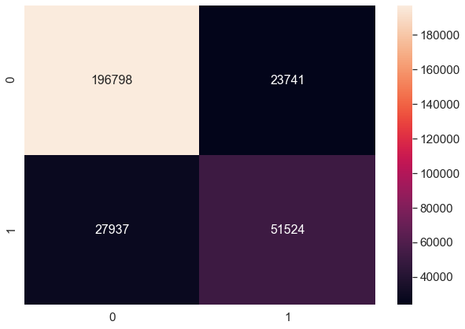

```python
import seaborn as sn
from sklearn.metrics import confusion_matrix

cm = confusion_matrix(y_train, y_train_pred)
df_cm = pd.DataFrame(cm, range(2), range(2))
sn.set(font_scale=1.4) # for label size
plt.figure(figsize=(10,7))
sn.heatmap(df_cm, annot=True, fmt='d', annot_kws={"size": 16}) # font size
plt.show()
```

```python
from sklearn.metrics import precision_score, recall_score
precision_score(y_train, y_train_pred)
```

```
0.6845678602271973
```

```python
#Sensitivity, True Positive Rate, Recall
recall_score(y_train, y_train_pred)
```

```
0.6484187211336379
```

```python
from sklearn.metrics import f1_score
f1_score(y_train, y_train_pred)
```

```
0.666003128110337
```

```python
y_scores = cross_val_predict(sgd_clf, X_train_final, y_train, cv=10, method="predict") #decison_function not supported
```

```python
from sklearn.metrics import precision_recall_curve

precisions, recalls, thresholds = precision_recall_curve(y_train, y_scores)
```

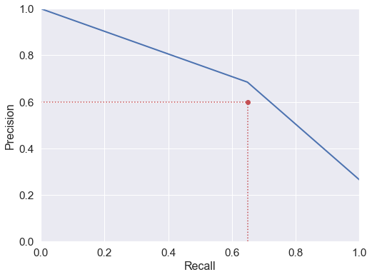

```python
def plot_precision_vs_recall(precisions, recalls):
    plt.plot(recalls, precisions, "b-", linewidth=2)
    plt.xlabel("Recall", fontsize=16)
    plt.ylabel("Precision", fontsize=16)
    plt.axis([0, 1, 0, 1])
    plt.grid(True)


recall_60_precision = recalls[np.argmax(precisions >= 0.60)]
threshold_60_precision = thresholds[np.argmax(precisions >= 0.60)]


plt.figure(figsize=(8, 6))
plot_precision_vs_recall(precisions, recalls)
plt.plot([recall_60_precision, recall_60_precision], [0., 0.60], "r:")
plt.plot([0.0, recall_60_precision], [0.60, 0.60], "r:")
plt.plot([recall_60_precision], [0.60], "ro")
plt.show()
```

```python
from sklearn.metrics import roc_curve

fpr, tpr, thresholds = roc_curve(y_train, y_scores)
```

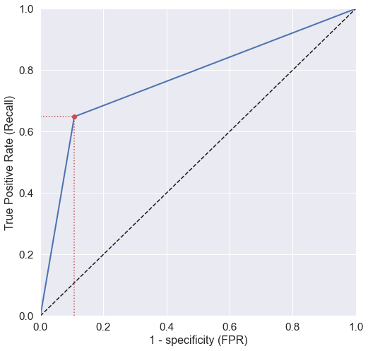

```python
def plot_roc_curve(fpr, tpr, label=None):
    plt.plot(fpr, tpr, linewidth=2, label=label)
    plt.plot([0, 1], [0, 1], 'k--')
    plt.axis([0, 1, 0, 1])
    plt.xlabel('1 - specificity (FPR)', fontsize=16)
    plt.ylabel('True Positive Rate (Recall)', fontsize=16)
    plt.grid(True)

plt.figure(figsize=(8, 8))
plot_roc_curve(fpr, tpr)
fpr_60 = fpr[np.argmax(tpr >= recall_60_precision)]
plt.plot([fpr_60, fpr_60], [0., recall_60_precision], "r:")
plt.plot([0.0, fpr_60], [recall_60_precision, recall_60_precision], "r:")
plt.plot([fpr_60], [recall_60_precision], "ro")
plt.show()
```

```python
from sklearn.ensemble import RandomForestClassifier
forest_clf = RandomForestClassifier(n_estimators=5, random_state=123)
y_pred_forest = cross_val_predict(forest_clf, X_train_final, y_train, cv=3,
                                    method="predict")
```

```python
predictions = pd.DataFrame(y_pred_forest, columns=['predictions']).to_csv('prediction_randomforest.csv')
```

```python
#Multicalss classification - Support Vector Machine classifier -
#One vs Rest classifier
#One vs One classifier

#Useless due to binary outcome
```

```python
#KNeighborsClassifier - too time expensive
```

[output not shown]